# COMPSCIX 415.2 Homework 3

Emerson Sosa

2/16/2019

## Libraries used:

```r
library(ggplot2)
library(nycflights13)
```

## Section 3.8.1 Exercises (all)

#### *1. What is the problem with this plot? How could you improve it?*

The problem with the first plot is that there are too many overlapping points on the graph. Using the `geom_jitter` aesthetic allows for a more accurate illustration of the data.

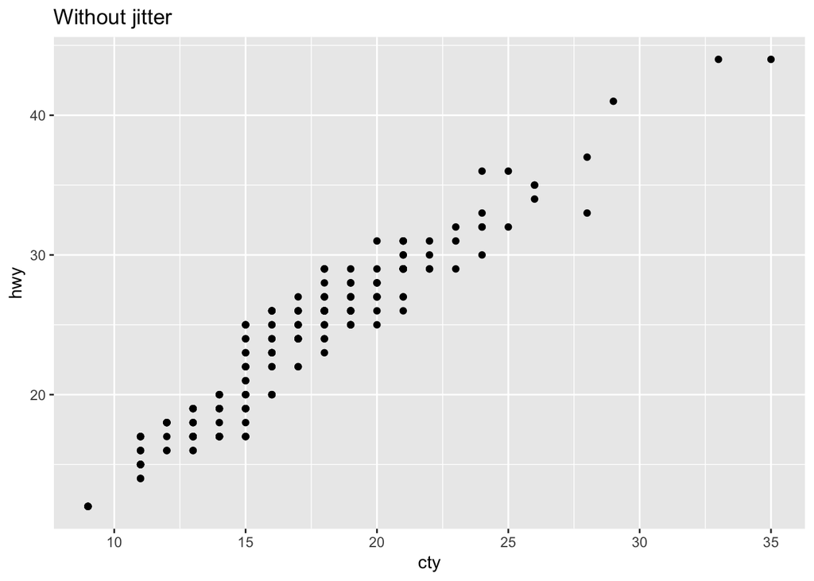

```r
ggplot(data = mpg, mapping = aes(x = cty, y = hwy)) +
  geom_point() +
  ggtitle("Without jitter")
```

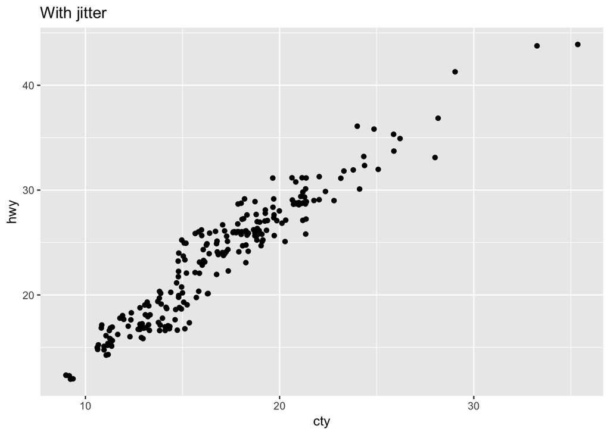

```r
ggplot(data = mpg, mapping = aes(x = cty, y = hwy)) +
  geom_jitter() +
  ggtitle("With jitter")
```

#### *2. What parameters to `geom_jitter()` control the amount of jittering?*

Using `height` and `width` will adjust the spread parameters. If not used, jitter will be set to 40% of the resolution.

```r
?geom_jitter
```

#### *3. Compare and contrast `geom_jitter()` with `geom_count`.*

The aesthetic `geom_jitter` gives a spread around the same observation while `geom_count` represents the overlapping values with area. A point that has at least 5 observations will have an area of 5 while a value that is observed at least 10 will have a corresponding area.

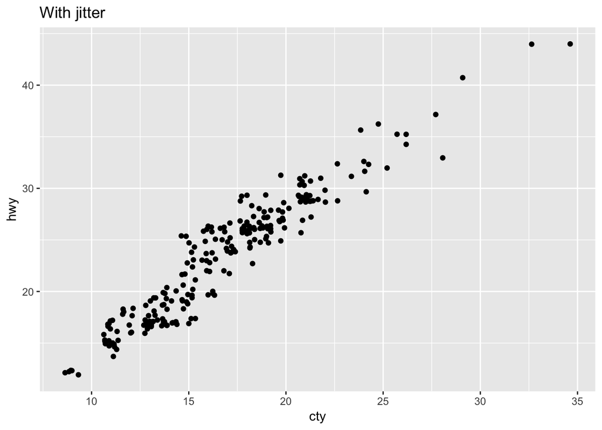

```r
?geom_count
ggplot(data = mpg, mapping = aes(x = cty, y = hwy)) +
  geom_jitter() +
  ggtitle("With jitter")
```

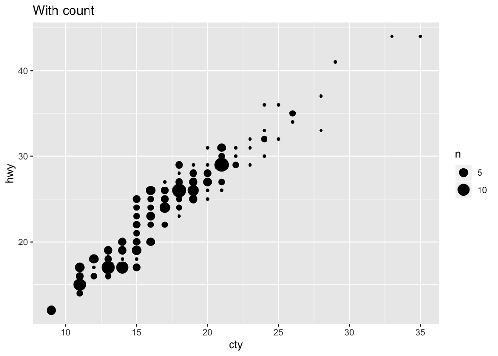

```r
ggplot(data = mpg, mapping = aes(x = cty, y = hwy)) +
 geom_count() +
  ggtitle("With count")
```

#### *4. What’s the default position for adjustment for `geom_boxplot()`? Create a visualization of the `mpg` dataset that demonstrates it.*

By looking up the aesthetic via `?geom_boxplot`, under the “Computed variables” section, it shows that the lower whisker is negative 1.5 X the interquartile range; the lower hinge is at the 25% quantile; middle is the median; upper hinge is the 75% quantile; ymax is positive 1.5 X the interquartile range.

The boxplot below shows the highway mpg for cars based on their wheel drive. The front wheel drive cars show the greatest mpg efficiency while 4 wheel drive and rear wheel drive are similar with rear wheel drive being more efficient and with less variability in obversations compared to 4 wheel drive.

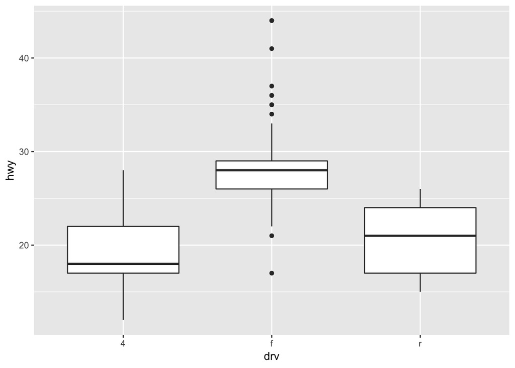

```r
?geom_boxplot
ggplot(mpg, aes(drv, hwy)) +
  geom_boxplot()
```

## Section 3.9.1 (2 and 4)

#### *2. What does `labs()` do?*

`labs()` gives the user the ability to add titles, subtitles, and captions to plots.

```r
?labs
```

#### *4. What does the plot below tell you about the relationship between city and highway mpg? Why is `coord_fixed()` important? What does `geom_abline()` do?*

Using the `geom_abline` as a reference where the slope is equal to 1, the plot shows that all cars have a higher mpg efficiency on the highway compared to the city (`geom_abline` creates a slope of the graph and include an x intercept). As cars become more efficient overall, their efficiency is increased on the highway as well. In other words, cars that are efficient overall do even better on the highway. `coord_fixed() is important because it creates a one-to-one proportionality between the scale on the x and y axis. This is important in this graph because the unit of measure, miles, should be seen as equal on both scales.

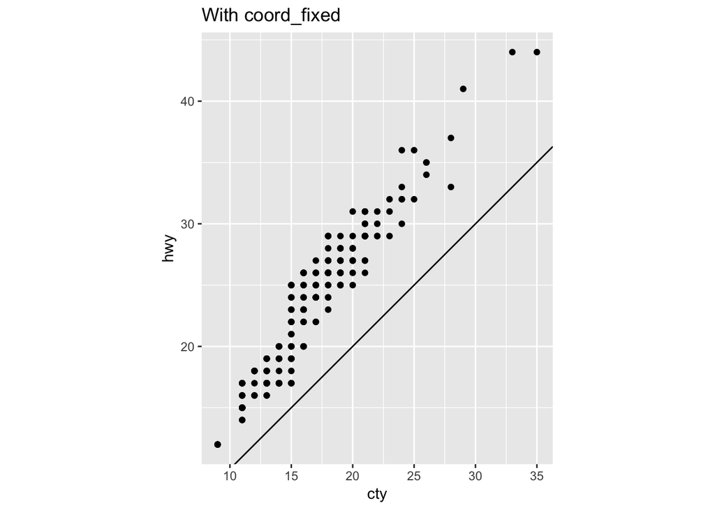

```r
ggplot(data = mpg, mapping = aes(x = cty, y = hwy)) +
  geom_point() +
  geom_abline() +
  coord_fixed(ratio = 1) +
  ggtitle("With coord_fixed")
```

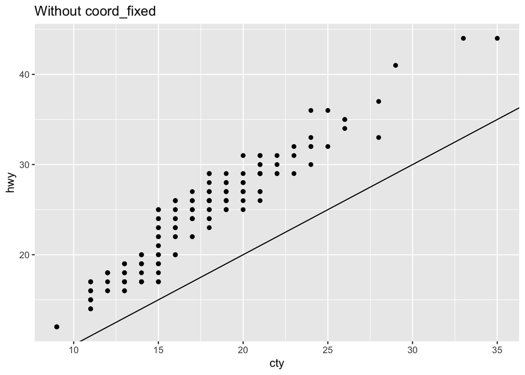

```r
ggplot(data = mpg, mapping = aes(x = cty, y = hwy)) +
  geom_point() +
  geom_abline() +
  ggtitle("Without coord_fixed")
```

```r
?coord_fixed
?geom_abline
```